# assignment 3

```r
install.packages("tidyverse")
library(tidyverse)
```

# 1)

### a) Read in (from the URL) and display (some of) the dataframe. How many observations and variables are there?

```r
url = "http://ritsokiguess.site/datafiles/gss-cat.csv"
gss_cat <- read_csv(url)
head(gss_cat)
```

| year | marital | age | race | rincome | partyid | relig | denom | tvhours |
| --- | --- | --- | --- | --- | --- | --- | --- | --- |
| 2000 | Never married | 26 | White | $8000 to 9999 | Ind,near rep | Protestant | Southern baptist | 12 |
| 2000 | Divorced | 48 | White | $8000 to 9999 | Not str republican | Protestant | Baptist-dk which | NA |
| 2000 | Widowed | 67 | White | Not applicable | Independent | Protestant | No denomination | 2 |
| 2000 | Never married | 39 | White | Not applicable | Ind,near rep | Orthodox-christian | Not applicable | 4 |
| 2000 | Divorced | 25 | White | Not applicable | Not str democrat | None | Not applicable | 1 |
| 2000 | Married | 25 | White | $20000 - 24999 | Strong democrat | Protestant | Southern baptist | NA |

### b) Display only the column that contains marital status.

```r
gss_cat %>% select(marital)
```

| marital |
| --- |
| Never married |
| Divorced |
| Widowed |
| Never married |
| Divorced |
| Married |
| Never married |
| Divorced |
| Married |
| Married |

[output cut: 990 more lines]

### c) Display all the quantitative columns, without naming any columns.

```r
gss_cat %>% select(where(is.numeric))
```

| year | age | tvhours |
| --- | --- | --- |
| 2000 | 26 | 12 |
| 2000 | 48 | NA |
| 2000 | 67 | 2 |
| 2000 | 39 | 4 |
| 2000 | 25 | 1 |
| 2000 | 25 | NA |
| 2000 | 36 | 3 |
| 2000 | 44 | NA |
| 2000 | 44 | 0 |
| 2000 | 47 | 3 |

[output cut: 990 more lines]

### d) Display only the observations for the 2012 survey.

```r
gss_cat %>% filter(year==2012)
```

| year | marital | age | race | rincome | partyid | relig | denom | tvhours |
| --- | --- | --- | --- | --- | --- | --- | --- | --- |
| 2012 | Never married | 22 | White | Not applicable | Ind,near dem | Catholic | Not applicable | 1 |
| 2012 | Never married | 21 | White | Not applicable | Ind,near rep | Catholic | Not applicable | NA |
| 2012 | Married | 42 | Other | $25000 or more | Ind,near dem | Protestant | No denomination | NA |
| 2012 | Married | 49 | White | Not applicable | Not str republican | Protestant | Presbyterian-dk wh | 4 |
| 2012 | Separated | 70 | Black | Not applicable | Strong democrat | Protestant | Southern baptist | 3 |
| 2012 | Widowed | 50 | White | Not applicable | Strong democrat | Protestant | Don't know | 4 |
| 2012 | Married | 35 | White | Not applicable | Independent | Christian | Not applicable | 3 |
| 2012 | Separated | 24 | Other | Not applicable | Independent | Catholic | Not applicable | NA |
| 2012 | Married | 28 | Black | Not applicable | Independent | None | Not applicable | NA |
| 2012 | Never married | 28 | White | $25000 or more | Strong democrat | None | Not applicable | NA |

[output cut: 990 more lines]

### e) For the people in the 2012 survey, how many of them were divorced, and what was the mean and standard deviation of age for those people? (I do not want to see anything about people in other years of survey or any other marital status.)

```r
gss_cat %>% filter(year==2012) %>%
  filter(marital=="Divorced") %>%
summarise(number_of_people = n(),mean = mean(age),sd = sd(age))
```

| number_of_people | mean | sd |
| --- | --- | --- |
| 316 | 54.00949 | 13.13024 |

In 2012, 316 people were divorced, mean of age is 54.00949 and standard deviation is 13.13024.

# 2)

### a)Read in and display some of the population.

```r
url = "http://ritsokiguess.site/datafiles/thepop.csv"
lln <- read_csv(url)
head(lln)
```

| y |
| --- |
| 2.755852 |
| 5.050202 |
| 7.309876 |
| 3.287517 |
| 1.531563 |
| 1.089346 |

### b) Draw a histogram of the population. What do you see from the histogram?

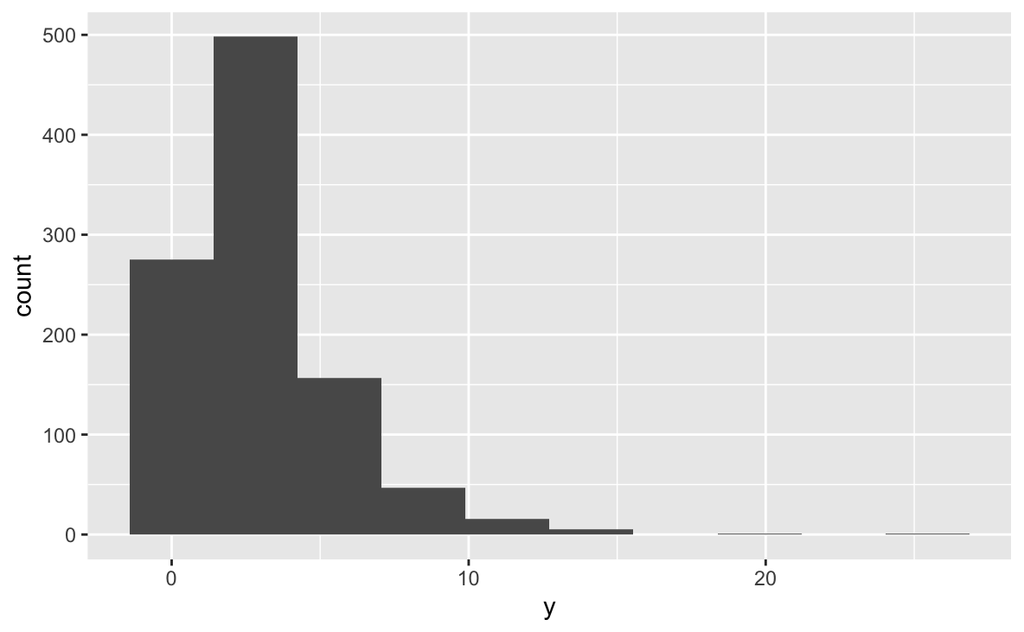

```r
ggplot(data = lln, aes(x = y)) + geom_histogram(bins=10)
```

The data is observably and strongly skewed to the right.

### c) Draw a large number of samples of size 5 without replacement from this population, work out the mean of each one, and make a plot of the means.

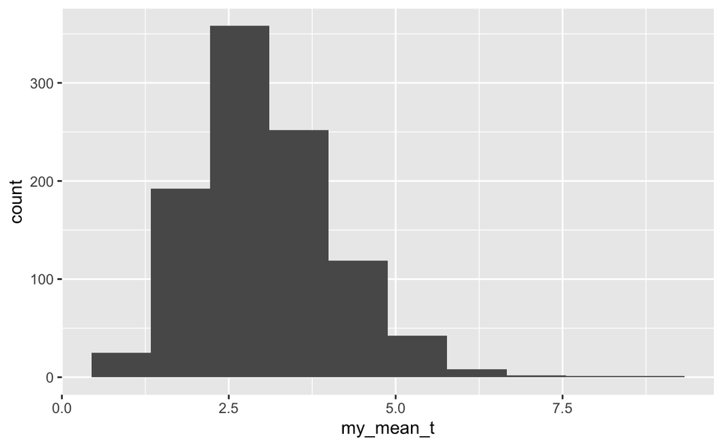

```r
tibble(sim = 1:1000) %>%
  rowwise() %>%
  mutate(sample = list(sample(lln$y, size = 5,replace = FALSE))) %>%
  mutate(my_mean_t = mean(sample)) %>%ggplot(aes(x=my_mean_t))+geom_histogram(bins=10)
```

### d) Repeat the previous part for samples of size 20.

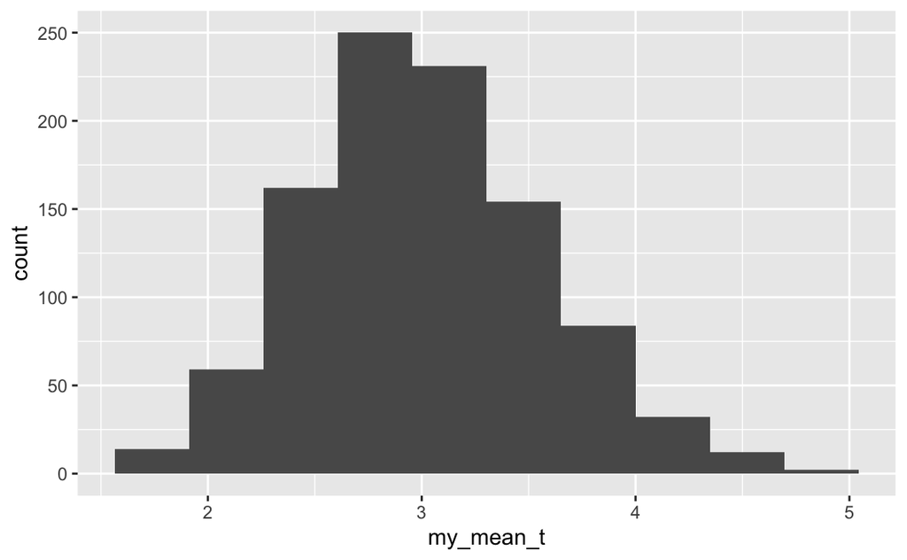

```r
tibble(sim = 1:1000) %>%
  rowwise() %>%
  mutate(sample = list(sample(lln$y, size = 20,replace = FALSE))) %>%
  mutate(my_mean_t = mean(sample)) %>%ggplot(aes(x=my_mean_t))+geom_histogram(bins=10)
```

### e) Repeat the previous part for samples of size 100.

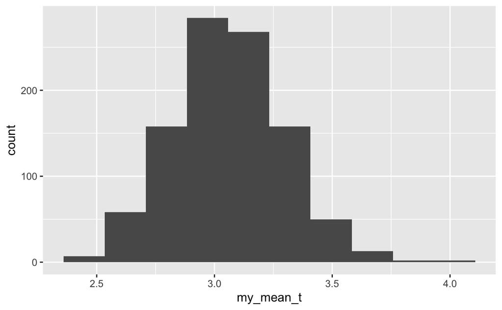

```r
tibble(sim = 1:1000) %>%
  rowwise() %>%
  mutate(sample = list(sample(lln$y, size = 100,replace = FALSE))) %>%
  mutate(my_mean_t = mean(sample)) %>%ggplot(aes(x=my_mean_t))+geom_histogram(bins=10)
```

### f) Explain as briefly as possible how your simulations illustrate the Law of Large Numbers.

```r
lln %>% summarise(mean(y))
```

| mean(y) |
| --- |
| 3.052996 |

The LLN states “As the sample size becomes large, the sample mean is going to have a higher probability of approaching the population mean”. And from c) to e) ,as the sample size increasing, there are more sample means near the population mean 3.05. Meanwhile，The distribution of data is also more centralized.